# DengAI_EDA

Oren Jalon

November 19, 2018

# DENGAI

The following code is my submission to the DengAI competition on DrivenData.org.

# DATA PREPARATION

Let’s begin by putting in the libraries we need and importing the data

## LIBRARIES

```r
library(tidyverse)
library(caret)
library(reshape2)
```

## IMPORT DATA

Make sure that the files are in the same working directory as this RMD file (– use getwd() to check –)

```r
d_train <- read_csv(file = "dengue_features_train.csv")
d_labels <- read_csv(file = "dengue_labels_train.csv")
d_test <- read_csv(file = "dengue_features_train.csv")
```

### Rescale the variables so that it is all in Celcius and mm

```r
d_train$reanalysis_dew_point_temp_k <- d_train$reanalysis_dew_point_temp_k - 273.15
d_test$reanalysis_dew_point_temp_k <- d_test$reanalysis_dew_point_temp_k - 273.15

d_train$reanalysis_air_temp_k <- d_train$reanalysis_air_temp_k - 273.15
d_test$reanalysis_air_temp_k <- d_test$reanalysis_air_temp_k - 273.15

d_train$reanalysis_max_air_temp_k <- d_train$reanalysis_max_air_temp_k - 273.15
d_test$reanalysis_max_air_temp_k <- d_test$reanalysis_max_air_temp_k - 273.15

d_train$reanalysis_min_air_temp_k <- d_train$reanalysis_min_air_temp_k - 273.15
d_test$reanalysis_min_air_temp_k <- d_test$reanalysis_min_air_temp_k - 273.15

d_train$reanalysis_avg_temp_k <- d_train$reanalysis_avg_temp_k - 273.15
d_test$reanalysis_avg_temp_k <- d_test$reanalysis_avg_temp_k - 273.15

#!!!tdtr does not appear to be in Kelvin
# d_train$reanalysis_tdtr_k <- d_train$reanalysis_tdtr_k - 273.15
# d_test$reanalysis_tdtr_k <- d_test$reanalysis_tdtr_k - 273.15

summary(d_train$reanalysis_dew_point_temp_k)
```

```
##    Min. 1st Qu.  Median    Mean 3rd Qu.    Max.    NA's
##   16.49   20.97   22.49   22.10   23.31   25.30      10
```

```r
summary(d_train$reanalysis_air_temp_k)
```

```
##    Min. 1st Qu.  Median    Mean 3rd Qu.    Max.    NA's
##   21.49   24.51   25.50   25.55   26.68   29.05      10
```

```r
summary(d_train$reanalysis_max_air_temp_k)
```

```
##    Min. 1st Qu.  Median    Mean 3rd Qu.    Max.    NA's
##   24.65   27.85   29.25   30.28   32.35   40.85      10
```

```r
summary(d_train$reanalysis_min_air_temp_k)
```

```
##    Min. 1st Qu.  Median    Mean 3rd Qu.    Max.    NA's
##   13.75   20.75   23.05   22.57   24.75   26.75      10
```

```r
summary(d_train$reanalysis_avg_temp_k)
```

```
##    Min. 1st Qu.  Median    Mean 3rd Qu.    Max.    NA's
##   21.74   25.11   26.14   26.08   27.06   29.78      10
```

```r
summary(d_train$reanalysis_tdtr_k)
```

```
##    Min. 1st Qu.  Median    Mean 3rd Qu.    Max.    NA's
##   1.357   2.329   2.857   4.904   7.625  16.029      10
```

We seem to have some missing values but we will investigate this more later.

Now let’s merge the datasets (train and labels) so that we can have the the features and the classifier in the same place. We will also split the dataset by city. Finally, we will merge the test and training set so that we can see what all the climate data looks like across the entire recorded period. This is just for exploration and will not be used for our analysis later.

## MERGE TRAIN & LABELS

```r
df <- merge(d_train, d_labels, by=c("city","year","weekofyear"))
```

## FILTER BY CITY (SJ, IQ)

```r
sj <- df[df$city == "sj",]
iq <- df[df$city == "iq",]
```

# INITIAL & EXPLORATORY ANALYSIS

Let’s review the summary statistics for the dataset. We will use the skimr library to get a cleaner view of the data.

## Summary Stats

```r
library(skimr)
skimmed.sj <- skim_to_wide(sj[,c(-1,-4)])
skimmed.sj
```

```
## # A tibble: 23 x 13
##    type   variable   missing complete n     mean   sd    p0    p25   p50
##    <chr>  <chr>      <chr>   <chr>    <chr> <chr>  <chr> <chr> <chr> <chr>
##  1 integ~ total_cas~ 0       936      936   "  34~ 51.38 0     "   ~ "  1~
##  2 integ~ weekofyear 0       936      936   "  26~ 15.02 1     "  1~ "  2~
##  3 integ~ year       0       936      936   1998.~ " 5.~ 1990  "199~ "199~
##  4 numer~ ndvi_ne    191     745      936   " 0.0~ " 0.~ "-0.~ " 0.~ " 0.~
##  5 numer~ ndvi_nw    49      887      936   " 0.0~ " 0.~ "-0.~ " 0.~ " 0.~
##  6 numer~ ndvi_se    19      917      936   " 0.1~ " 0.~ -0.0~ " 0.~ " 0.~
##  7 numer~ ndvi_sw    19      917      936   " 0.1~ " 0.~ -0.0~ " 0.~ " 0.~
##  8 numer~ precipita~ 9       927      936   "35.4~ "44.~ " 0 ~ " 0 ~ "20.~
##  9 numer~ reanalysi~ 6       930      936   "26.0~ " 1.~ "22.~ "25.~ "26.~
## 10 numer~ reanalysi~ 6       930      936   "26.1~ " 1.~ "22.~ "25.~ "26.~
## # ... with 13 more rows, and 3 more variables: p75 <chr>, p100 <chr>,
## #   hist <chr>
```

```r
skimmed.iq <- skim_to_wide(iq[,c(-1,-4)])
skimmed.iq
```

```
## # A tibble: 23 x 13
##    type   variable   missing complete n     mean   sd    p0    p25   p50
##    <chr>  <chr>      <chr>   <chr>    <chr> <chr>  <chr> <chr> <chr> <chr>
##  1 integ~ total_cas~ 0       520      520   "   7~ 10.77 0     "   ~ "   ~
##  2 integ~ weekofyear 0       520      520   "  26~ 15.03 1     "  1~ "  2~
##  3 integ~ year       0       520      520   "2005~ " 2.~ 2000  2002~ "200~
##  4 numer~ ndvi_ne    3       517      520   " 0.2~ " 0.~ " 0.~ " 0.~ " 0.~
##  5 numer~ ndvi_nw    3       517      520   " 0.2~ " 0.~ " 0.~ " 0.~ " 0.~
##  6 numer~ ndvi_se    3       517      520   " 0.2~ " 0.~ " 0.~ " 0.~ " 0.~
##  7 numer~ ndvi_sw    3       517      520   " 0.2~ " 0.~ " 0.~ " 0.~ " 0.~
##  8 numer~ precipita~ 4       516      520   64.25  "35.~ " 0 ~ 39.11 60.47
##  9 numer~ reanalysi~ 4       516      520   24.72  " 1.~ "21.~ 23.94 24.67
## 10 numer~ reanalysi~ 4       516      520   25.98  " 1.~ "21.~ 25.07 25.97
## # ... with 13 more rows, and 3 more variables: p75 <chr>, p100 <chr>,
## #   hist <chr>
```

```r
rm(skimmed.sj, skimmed.iq)
```

We can see that SJ has 936 weeks with a mean of 34.2 cases per week. IQ has 520 weeks with a mean of 7.6 weekly cases. There are no missing values for our total cases classifer but there are climate data features which have many missing values.

In this section, we summary the value of the data frames (together and by city). We also create the following graphs

1. Wilcoxon test for test of means between cities
2. Frequency histograms
3. Bivariate analysis - line graphs for time analysis
4. Bivariate analysis - box plot by week for determining seasonality
5. Bivariate analysis - total cases by time and by week
6. Bivariate analysis - scatterplot for total_cases by other variables

## Compare the means between same variables in different cities

We need to know if the two cities should be analysed together or separately. Let’s do a wilcoxon test (non-parametric) to compare the means of the same climate features between the two different cities.

```r
cnames <- colnames(sj)
for (i in 5:(ncol(sj))){
  wilt <- wilcox.test(sj[,i],iq[,i])
  print(cnames[i])
  print(wilt)
}
```

```
## [1] "ndvi_ne"
##
##  Wilcoxon rank sum test with continuity correction
##
## data:  sj[, i] and iq[, i]
## W = 21691, p-value < 2.2e-16
## alternative hypothesis: true location shift is not equal to 0
##
## [1] "ndvi_nw"
##
##  Wilcoxon rank sum test with continuity correction
##
## data:  sj[, i] and iq[, i]
## W = 32596, p-value < 2.2e-16
## alternative hypothesis: true location shift is not equal to 0
##
## [1] "ndvi_se"
##
##  Wilcoxon rank sum test with continuity correction
##
## data:  sj[, i] and iq[, i]
## W = 107990, p-value < 2.2e-16
## alternative hypothesis: true location shift is not equal to 0
##
## [1] "ndvi_sw"
##
##  Wilcoxon rank sum test with continuity correction
##
## data:  sj[, i] and iq[, i]
## W = 78560, p-value < 2.2e-16
## alternative hypothesis: true location shift is not equal to 0
##
## [1] "precipitation_amt_mm"
##
##  Wilcoxon rank sum test with continuity correction
##
## data:  sj[, i] and iq[, i]
## W = 118470, p-value < 2.2e-16
## alternative hypothesis: true location shift is not equal to 0
##
```

[output cut: 112 more lines]

```
## [1] "station_precip_mm"
##
##  Wilcoxon rank sum test with continuity correction
##
## data:  sj[, i] and iq[, i]
## W = 142000, p-value < 2.2e-16
## alternative hypothesis: true location shift is not equal to 0
##
## [1] "total_cases"
##
##  Wilcoxon rank sum test with continuity correction
##
## data:  sj[, i] and iq[, i]
## W = 401310, p-value < 2.2e-16
## alternative hypothesis: true location shift is not equal to 0
```

```r
rm(cnames, i, wilt)
```

We can see that the same feature is significantly different in each city (look at the p-values)

## GRAPH: Frequency histogram of all variables in training set for **SJ**

Let’s review the distribution of each of the variables. Some appear to be normally distributed while others are not.

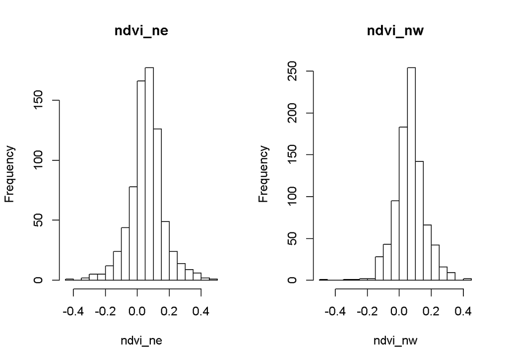

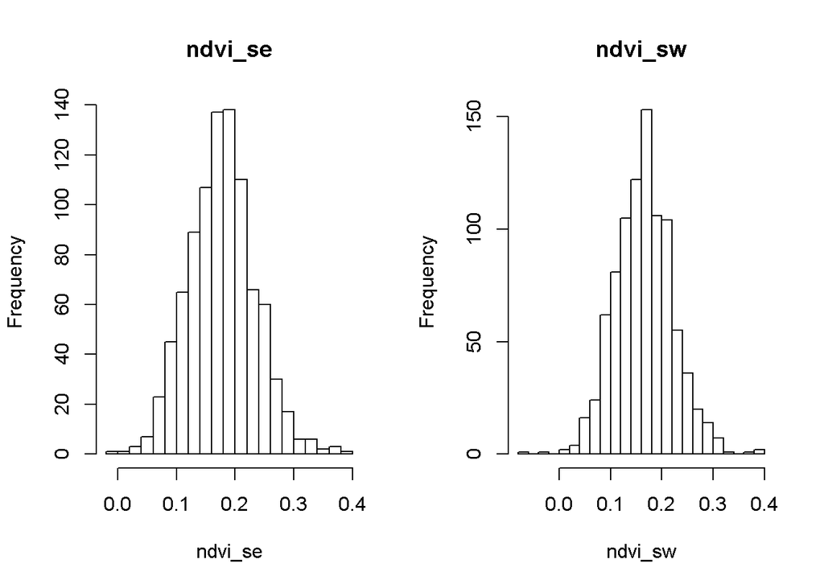

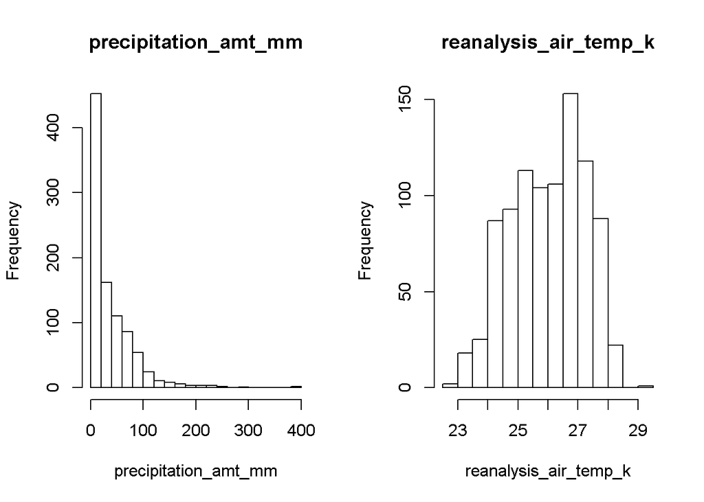

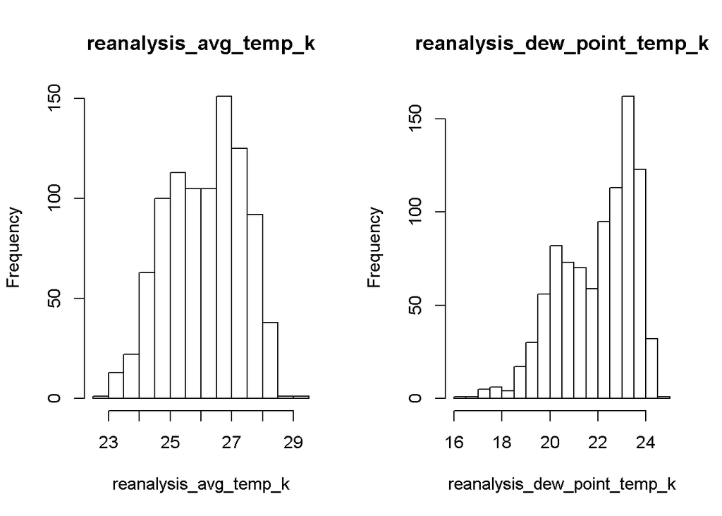

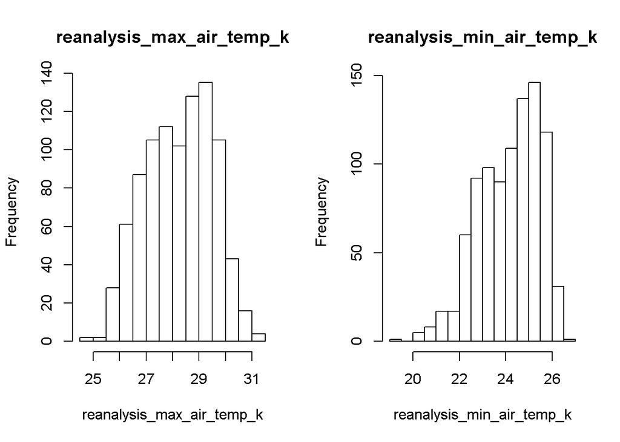

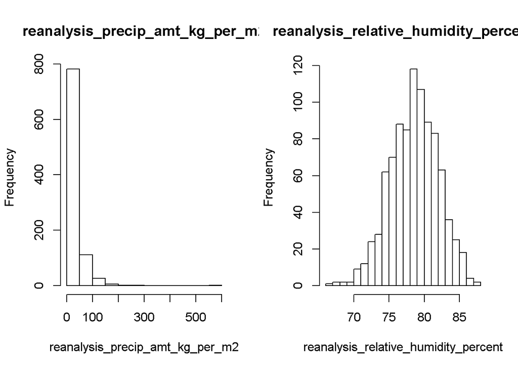

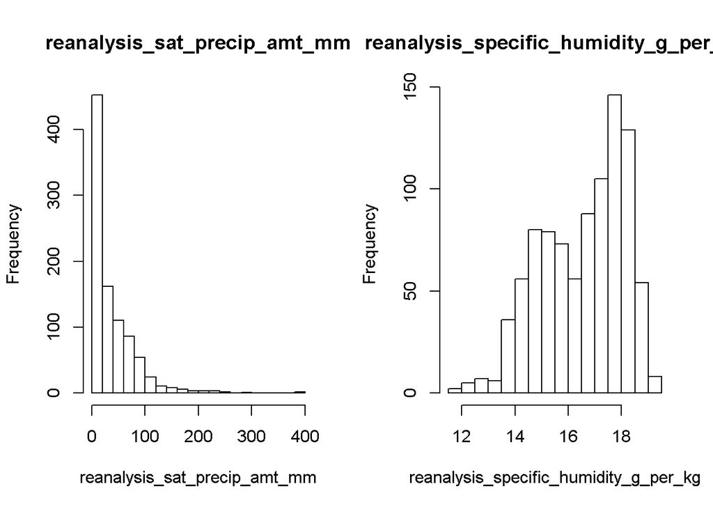

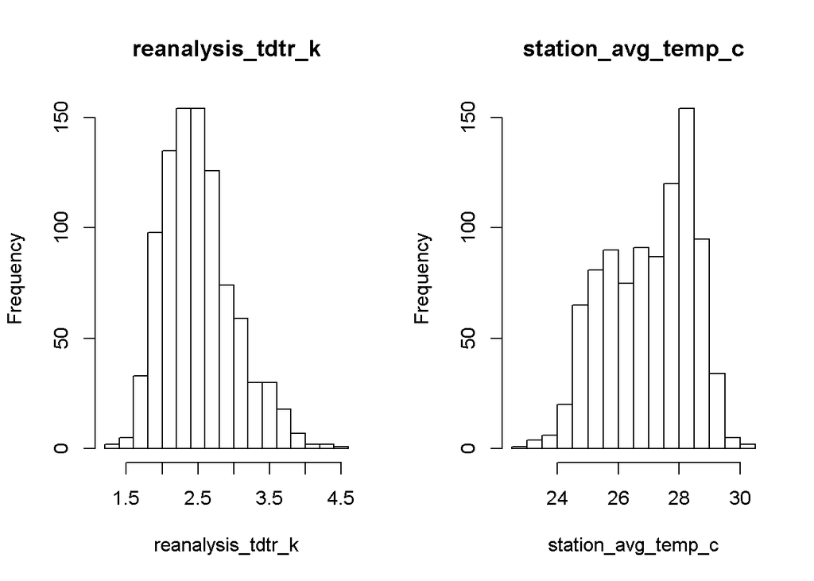

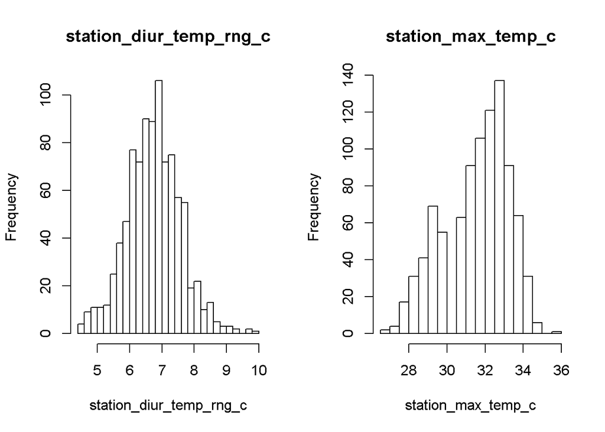

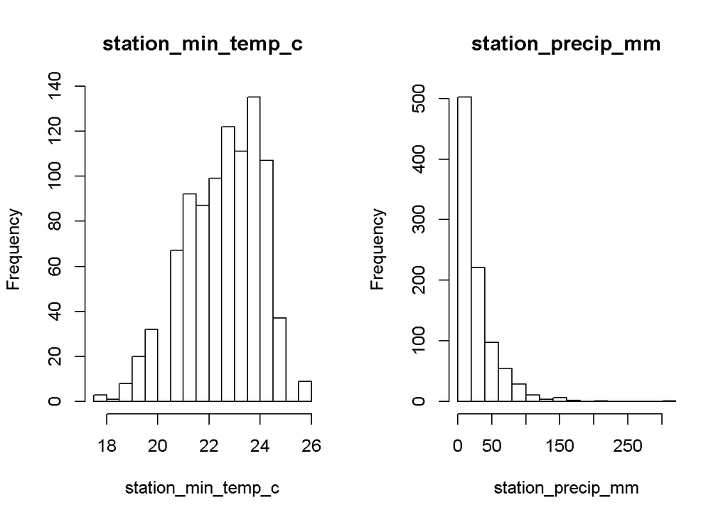

```r
cnames <- colnames(sj)
par(mfrow=c(1,2))
for (i in 5:ncol(sj)) {
  hist(sj[,i],
      breaks = 20,
      xlab = cnames[i],
      main = paste(cnames[i], sep = ": "))
}
```

```r
rm(cnames, i)
```

[figure not shown]

## GRAPH: Frequency histogram of all variables in training set for **IQ**

Same as above but only for IQ.

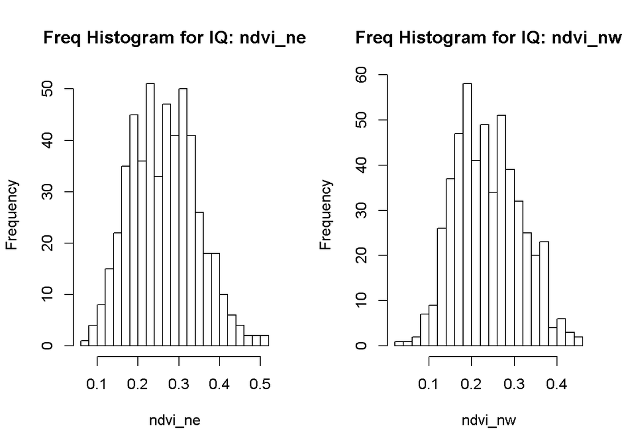

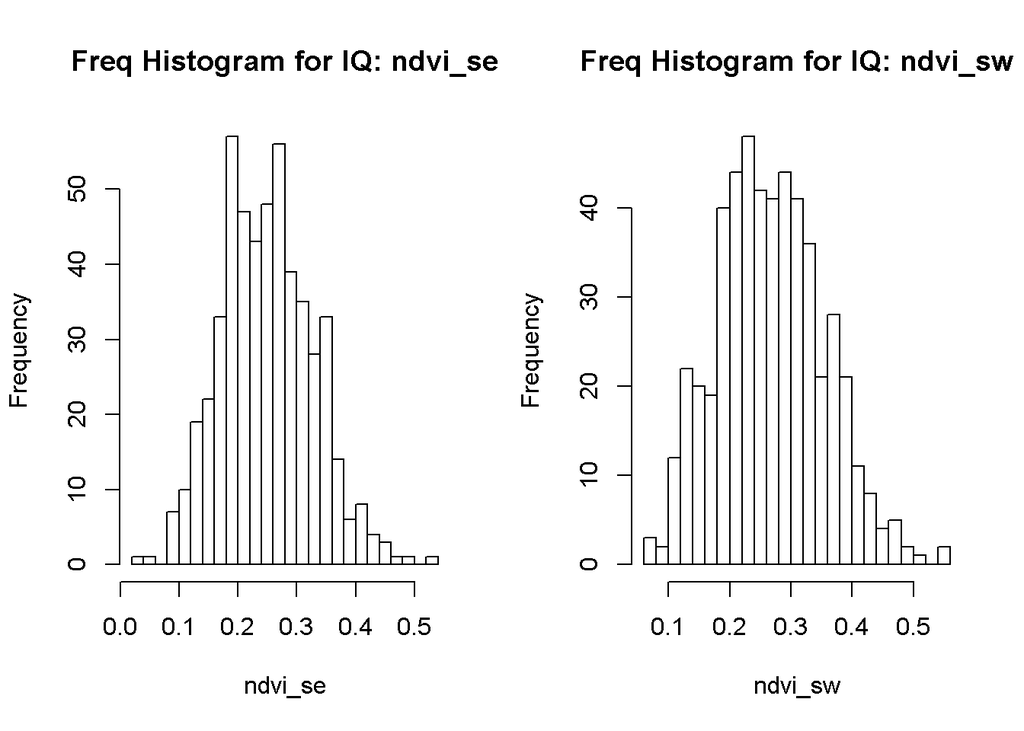

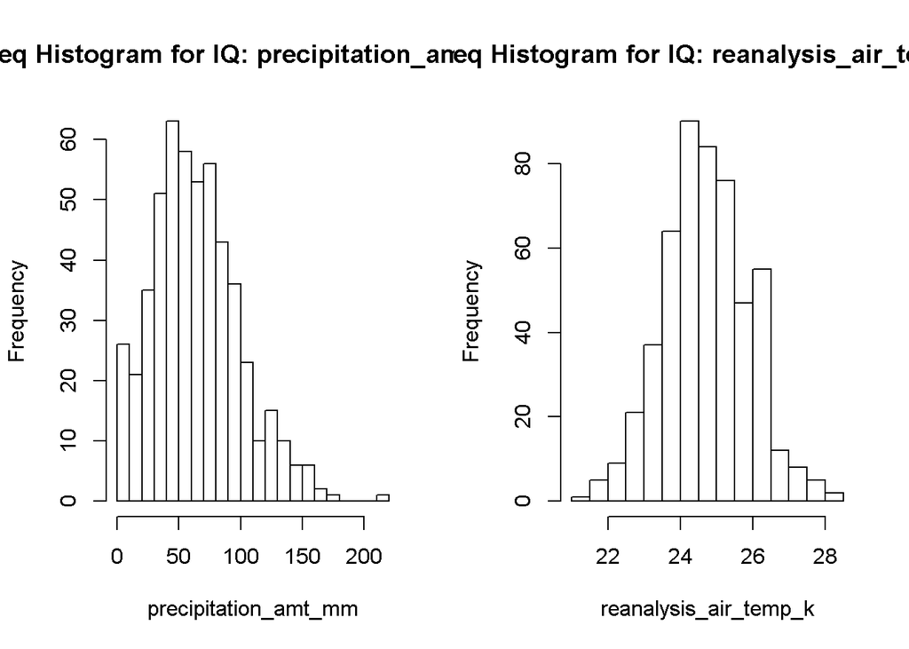

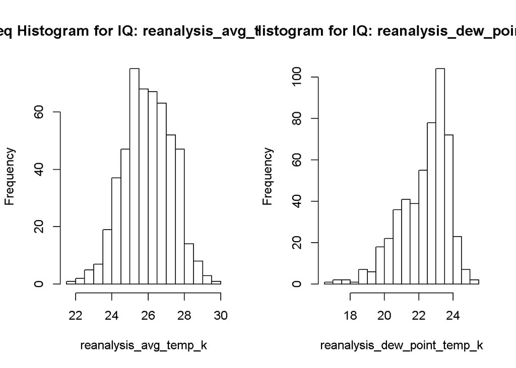

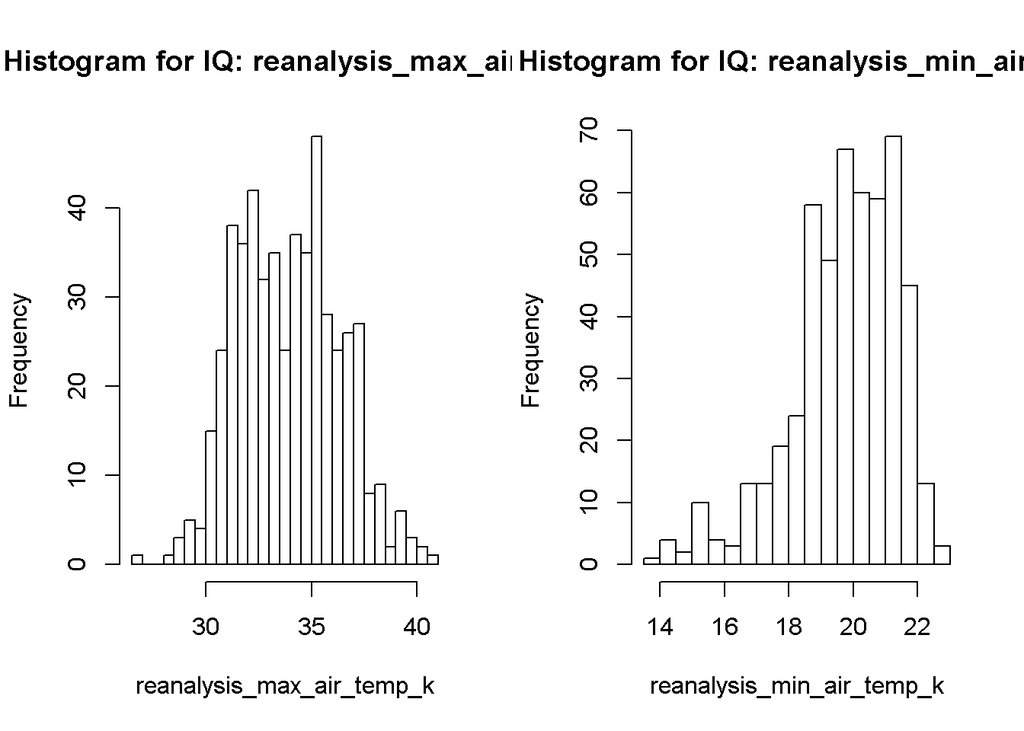

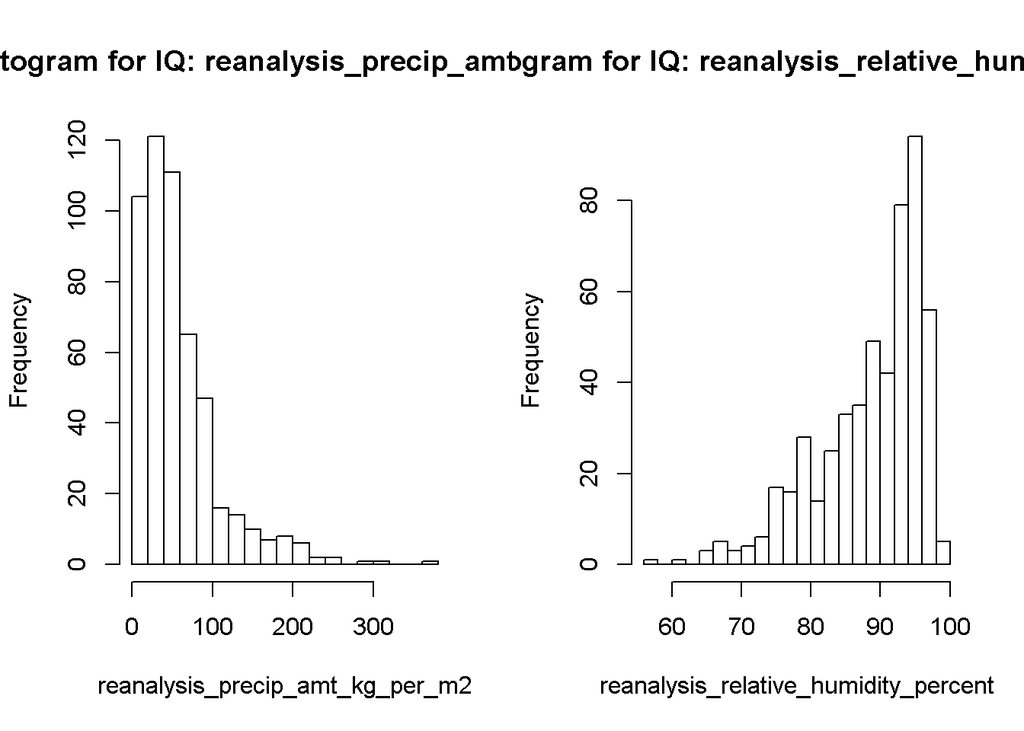

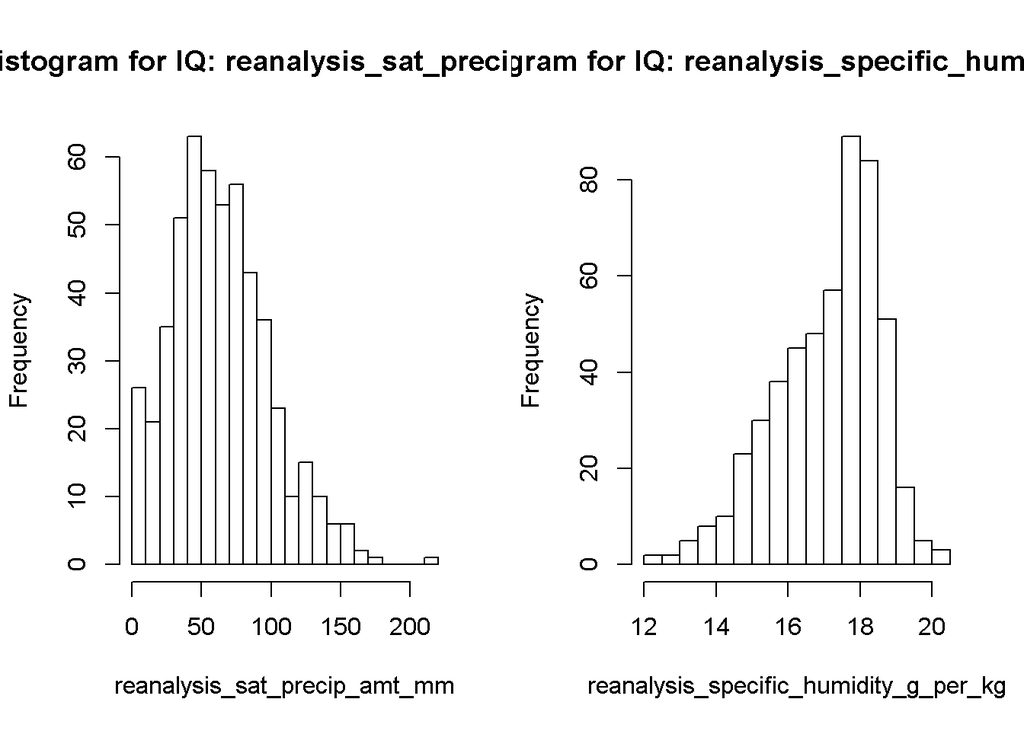

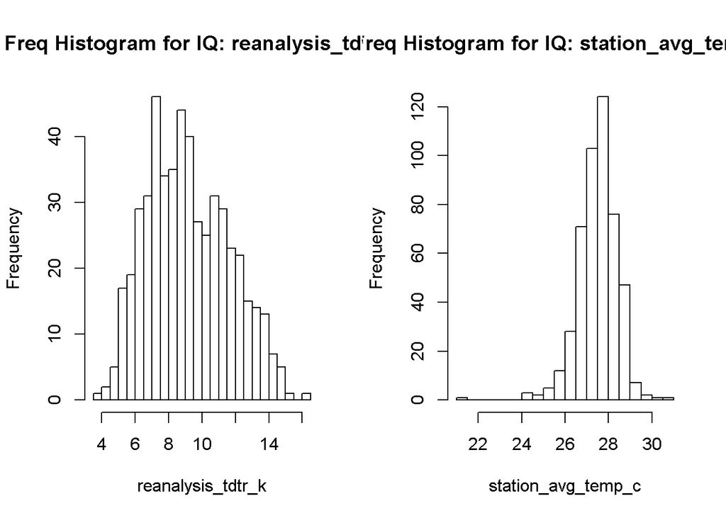

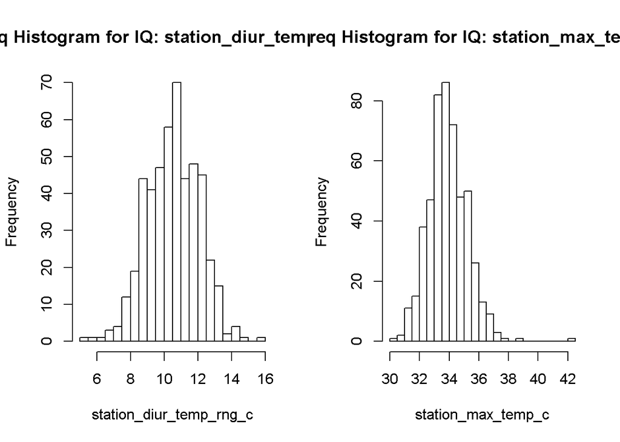

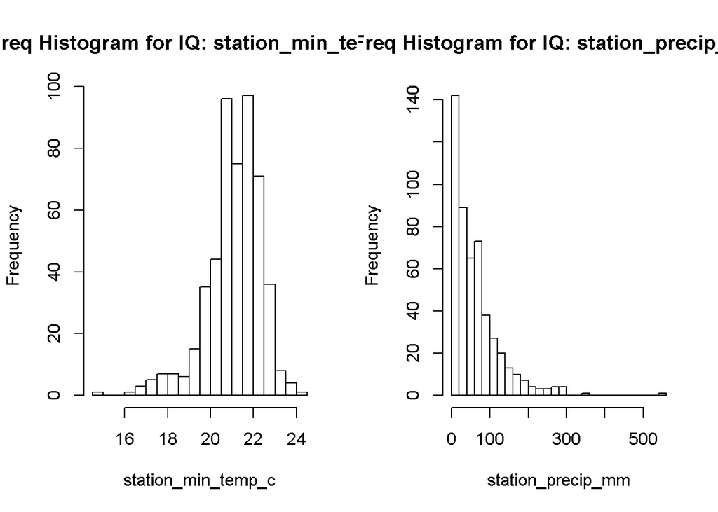

```r
cnames <- colnames(df)
par(mfrow=c(1,2))
for (i in 5:(ncol(df))) {
 hist(df[df$city == "iq",i],
      breaks = 20,
      xlab = cnames[i],
      main = paste("Freq Histogram for IQ", cnames[i], sep = ": "))
}
```

```r
rm(cnames, i)
```

[figure not shown]

## GRAPH: Climate variables by time for **SJ**

Here we are reviewing the data by time for SJ